# Jupiter: The Giant and Its Moons

Unit 3: Revolution · the featured planet · Astronomy

[figure not shown]

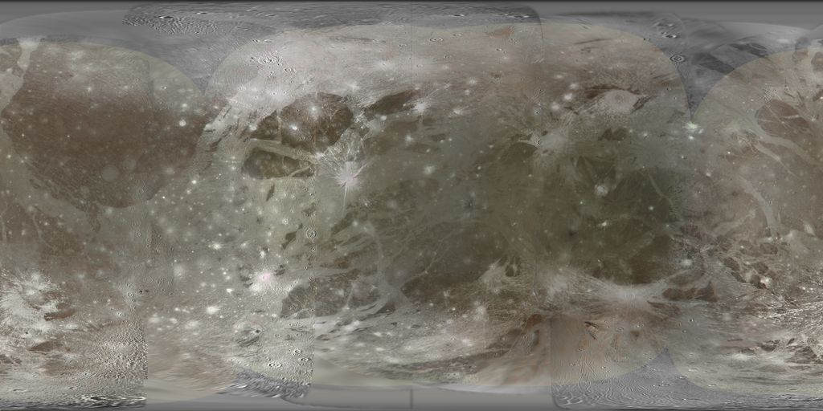

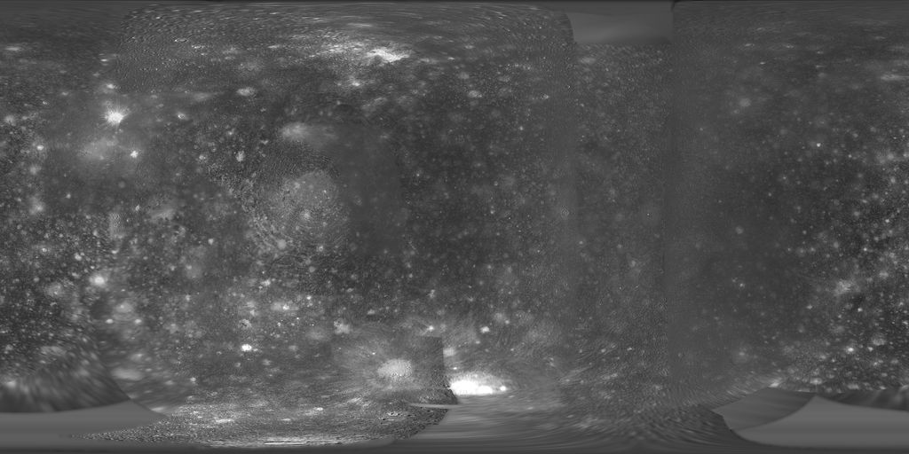

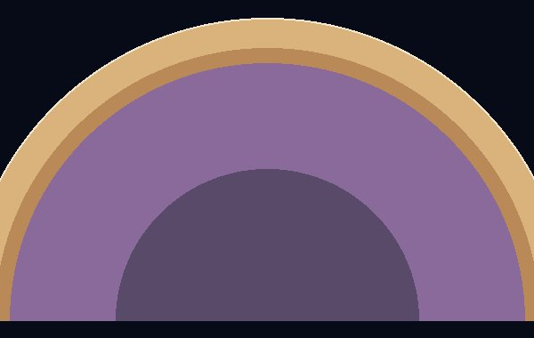

[interactive chart not shown]

Jupiter is a giant ball of gas, 11 times as wide as Earth, with no solid ground to stand on. Its clouds are pulled into stripes by winds faster than any hurricane, and one of its storms is bigger than our whole planet. Four large moons circle it, and you can see them with binoculars.

Jupiter rises in the evening from January. On **11 February 2027** it is opposite the Sun, the brightest thing in the night sky after the Moon and Venus.

Today: watch Jupiter's clouds, weigh it with its moons, and meet Io and Europa.

Jupiter map: Hubble OPAL 2025 (NASA, ESA, A. Simon, M. H. Wong). Open the Jupiter app to spin it and watch the moons tonight.

## Jupiter at a glance

🌍

Size

radius 71,492 km · more than 1,300 Earths would fit inside

⚖️

318 Earths

Mass

more than all the other planets put together, twice over

☀️

5.2 AU

Distance from the Sun

sunlight takes 43 minutes to get there

🌀

9 h 56 min

One day

the fastest spin of any planet

📅

11.9 years

One year

it moves about one zodiac constellation each year

🪐

4 big moons

Galilean moons

Io, Europa, Ganymede, Callisto · 115 moons known in all (NASA, Sept 2026)

🏋️

Gravity at the cloud tops

a 150 lb student would weigh about 380 lb

## Seven things to explore

Click a tile. You don’t need all seven.

[figure not shown]

1

Belts, zones and winds

stripes that race each other

[figure not shown]

2

The Great Red Spot

a storm bigger than Earth

[figure not shown]

3

Weigh Jupiter

Kepler's 3rd law, with moons

[figure not shown]

4

Inside Jupiter

a trip to the centre

[figure not shown]

5

Io, the volcano moon

squeezed until it melts

[figure not shown]

6

Europa and Ganymede

oceans under the ice

[figure not shown]

7

Magnetosphere and radiation

an invisible bubble, and why it's deadly

← scroll the tiles →

### Belts, zones and winds

Jupiter's stripes come in two kinds. The bright **zones** are high, white clouds of ammonia ice where gas is rising. The darker **belts** are where gas sinks, and we see deeper, browner clouds. Along the edges between them blow **jets**, winds up to about 150 m/s (340 mph), some east and some west.

Watch the bands slide past each other

[interactive chart not shown]

Each strip moves at its measured wind speed (sped up 50,000 times: one real second is about 14 hours). The chart on the right is the wind at each latitude.

Measure: how fast is a cloud at the equator moving?

Jupiter's radius is 71,492 km and it turns once every 9.93 hours. Use $v = \dfrac{\Delta x}{\Delta t}$ for one trip around.

**Reveal**

$\Delta x = 2\pi R = 2\pi(71{,}492\ \text{km}) = 449{,}000$ km and $\Delta t = 9.93\ \text{h} = 35{,}700$ s, so $v = \dfrac{449{,}000\ \text{km}}{35{,}700\ \text{s}} = \boxed{12.6\ \text{km/s}}$: about 28,000 mph, just from spinning. Earth's equator moves at 0.46 km/s.

Measure: how long does the fastest jet take to lap Jupiter?

The fastest jet blows 150 m/s at 24°N, where the distance around is $2\pi R\cos 24^\circ$.

**Reveal**

$\Delta x = 2\pi(71{,}492\ \text{km})\cos 24^\circ = 410{,}000$ km $= 4.1\times10^{8}$ m. $\Delta t = \dfrac{\Delta x}{v} = \dfrac{4.1\times10^{8}\ \text{m}}{150\ \text{m/s}} = 2.7\times10^{6}$ s $\approx \boxed{32\ \text{days}}$ to lap the planet, on top of the spin.

### The Great Red Spot

The **Great Red Spot** is a storm that has been spinning for at least 150 years. It turns **counterclockwise** about once every six days, trapped between a jet blowing west on its north side and one blowing east on its south side. It is **shrinking**, and nobody knows whether it will disappear. Farther south sits its little cousin, **Oval BA** ("Red Spot Jr."), about as wide as Earth, made when three white storms merged around 2000.

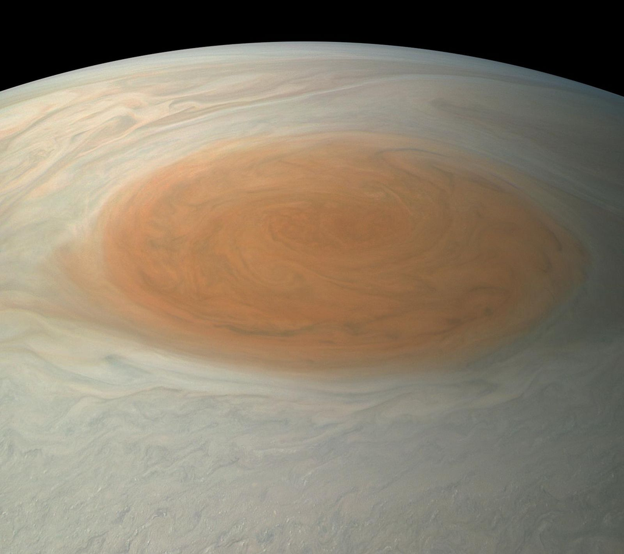

**The Great Red Spot from Juno**, 10 July 2017, from 13,900 km above the clouds, in true colour. Enhanced by Björn Jónsson (CC BY-NC-SA), from NASA/JPL-Caltech/SwRI/MSSS data

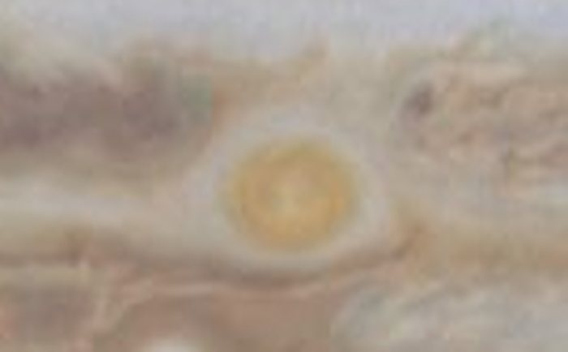

**Oval BA**, December 2025, at 33°S. Hubble OPAL (NASA, ESA, A. Simon, M. H. Wong)

Measure it: click the Spot's west end, then its east end

[interactive chart not shown]

2015: click both ends.

[interactive chart not shown]

2025: click both ends.

Both pictures are drawn at the same scale. At 22°S, one degree of longitude is $\dfrac{2\pi R\cos 22^\circ}{360} \approx 1{,}160$ km. Earth is 12,740 km wide.

Predict first: how long will it be in 2040? Click the chart.

[interactive chart not shown]

Astronomers have measured the Spot's length since 1880. Click where you think the 2040 point will be.

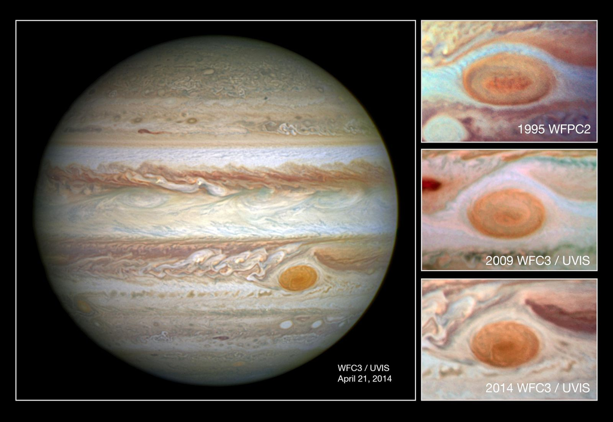

**Shrinking:** about 21,000 km wide in 1995, 18,000 km in 2009, 16,000 km in 2014. NASA, ESA, A. Simon (GSFC)

### Weigh Jupiter

In January 1610 Galileo turned his telescope on Jupiter and saw four "stars" that moved back and forth beside it every night. They were moons going around Jupiter: proof that not everything circles the Earth. Kepler's third law works for them too, with Jupiter in place of the Sun, so the moons tell us **Jupiter's mass**.

[figure not shown]

**The Great Red Spot and the four big moons**, all to the same scale. Top to bottom: Io, Europa, Ganymede, Callisto. NASA/JPL/DLR

Guess first: tap the moons from shortest orbit to longest

[interactive chart not shown]

To remember the order, closest first: **I Eat Green Cheese**, for Io, Europa, Ganymede, Callisto.

Weigh Jupiter with Europa

Europa orbits 671,000 km from Jupiter's centre every 3.551 days. Use $P^2_{yr} = \dfrac{a^3_{\rm AU}}{M_\star}$ with 1 AU $= 1.5\times10^{8}$ km, and solve for $M_\star$ (here the "star" is Jupiter).

**Reveal**

$a = \dfrac{6.71\times10^{5}\ \text{km}}{1.5\times10^{8}\ \text{km/AU}} = 4.47\times10^{-3}$ AU and $P = \dfrac{3.551}{365.25} = 9.72\times10^{-3}$ yr.  
$M = \dfrac{a^3}{P^2} = \dfrac{(4.47\times10^{-3})^3}{(9.72\times10^{-3})^2} = \boxed{9.5\times10^{-4}\ M_\odot}$, about $\dfrac{1}{1050}$ of the Sun, or 315 Earths. Try it with Io, Ganymede or Callisto from the chart: you get the same Jupiter every time.

Collect the positions yourself, night by night, in the app's Weigh Jupiter mode.

### Inside Jupiter

Jupiter has no ground. Fall through the clouds and the hydrogen gas just gets thicker and hotter until it behaves like a liquid. Deeper still, the pressure squeezes hydrogen so hard it becomes **metallic hydrogen**, a liquid metal that carries electric current. Its swirling makes Jupiter's huge magnetic field. At the centre, the Juno spacecraft found a **"fuzzy" core**: rock and ice mixed into the hydrogen, spread over a big part of the planet instead of packed into a small ball.

Take a trip to the centre: drag the slider down

Depth**cloud tops**

[interactive chart not shown]

Layer depths, temperatures and pressures are approximate: they come from computer models fitted to Juno's measurements of Jupiter's gravity.

Measure: how dense is Jupiter?

Use the mass you found in "Weigh Jupiter", $M = 9.5\times10^{-4}\,M_\odot = 1.9\times10^{27}$ kg, and Jupiter's radius, $7.0\times10^{7}$ m. Density is mass divided by volume, $\rho = \dfrac{M}{\frac{4}{3}\pi R^3}$.

**Reveal**

$V = \tfrac{4}{3}\pi(7.0\times10^{7}\ \text{m})^3 = 1.4\times10^{24}\ \text{m}^3$, so $\rho = \dfrac{1.9\times10^{27}\ \text{kg}}{1.4\times10^{24}\ \text{m}^3} = \boxed{1{,}300\ \text{kg/m}^3}$, or 1.3 g/cm³. Water is 1.0 and rock is about 3; Earth averages 5.5. So Jupiter must be made mostly of the lightest stuff there is: hydrogen and helium. (Saturn's average density is less than water's. More on that in Unit 4.)

**What keeps Jupiter warm?** Three things. **The Sun** warms it from outside. But Jupiter gives off about **twice** as much heat as it gets from sunlight, so the other half comes from inside: mostly **heat left over from when it formed**, leaking out as the planet very slowly shrinks, plus a smaller share from **helium rain**, since falling droplets release energy. On Saturn, helium rain matters even more.

### Io, the volcano moon

Io is about the size of our Moon, and it is the most volcanic place we know, with more than 400 active volcanoes. Its orbit is slightly stretched, so Jupiter's pull squeezes it harder when it is close and less when it is far, over and over, like squeezing a rubber ball until it warms up. That **tidal heating** melts rock inside Io. Europa and Ganymede keep tugging Io's orbit back into that stretched shape, so the squeezing never stops.

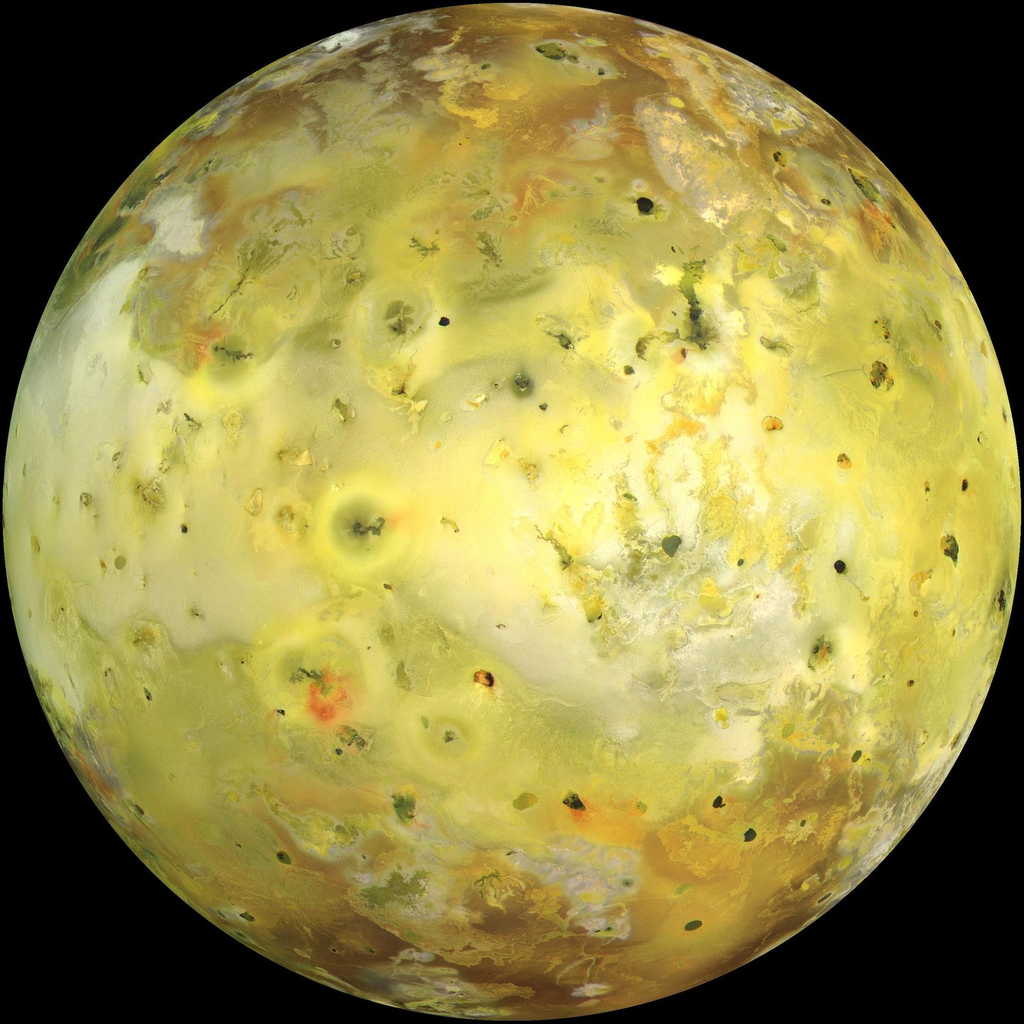

**Io** from Galileo, 1999, about as your eye would see it. Yellow and orange sulfur, dark lava. NASA/JPL/University of Arizona

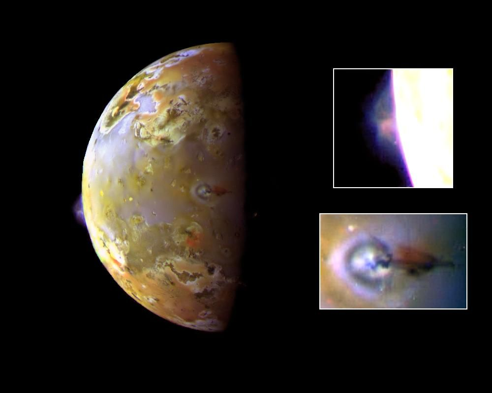

**Two plumes**: Pillan, 140 km high on Io's edge (top), and Prometheus, 75 km high, with its shadow (bottom). NASA/JPL

Measure: how fast does a plume shoot up?

Io's mass is $8.93\times10^{22}$ kg and its radius is $1.82\times10^{6}$ m. The biggest plumes, from the volcano Pele, reach about 300 km. First find $g = \dfrac{GM}{r^2}$ on Io, then use a LOL diagram: all the $KE$ at the vent becomes $PE$ at the top.

**Reveal**

$g = \dfrac{(6.67\times10^{-11})(8.93\times10^{22})}{(1.82\times10^{6})^2} = 1.8\ \text{m/s}^2$ (about the same as our Moon).  
$\tfrac{1}{2}mv^2 = mgh \Rightarrow v = \sqrt{2gh} = \sqrt{2(1.8)(3\times10^{5})} = \boxed{1{,}000\ \text{m/s}}$, about three times the speed of sound on Earth. (The mass $m$ cancels; $g$ also weakens a little on the way up, so this is an estimate.)

Same launch speed, two worlds

Launch speed**1000 m/s**

[interactive chart not shown]

The ground itself has tides

Io's solid rock rises and falls by **tens of metres** every orbit (NASA estimates up to 100 m), as it swings closer to Jupiter and farther away. On Earth, the ground under your feet rises and falls too, by about **30 to 40 cm** twice a day, but nobody notices.

[interactive chart not shown]

The stretch is exaggerated about 1,000 times so you can see it. The readout uses NASA's upper estimate; measurements from Juno suggest the real flexing may be smaller.

### Europa and Ganymede: oceans under the ice

Europa is a little smaller than our Moon and covered in ice crossed by long cracks. Under the ice is a **salty ocean**, kept liquid by the same tidal squeezing that heats Io. In 2025 Juno measured the cold outer ice at about 29 km thick; the ocean below may be 60 to 150 km deep. Where there is liquid water, energy and the right chemicals, there might be life, which is why NASA sent **Europa Clipper**. It launched in October 2024 and arrives at Jupiter in April 2030.

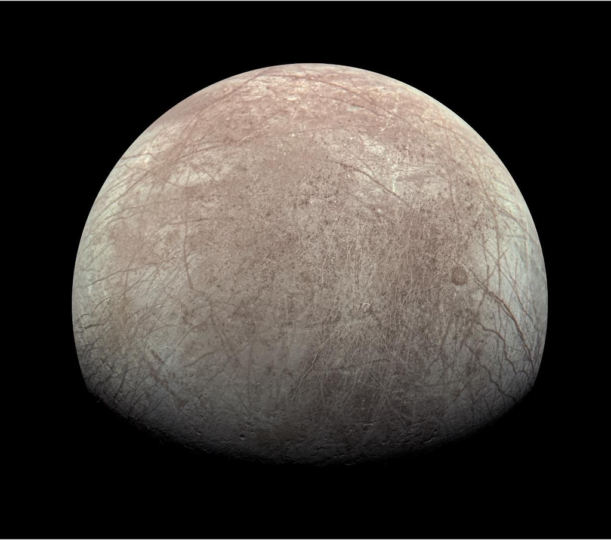

**Europa from Juno**, 29 Sept 2022: ridges and cracks everywhere. Image data NASA/JPL-Caltech/SwRI/MSSS; processing Kevin M. Gill (CC BY 3.0)

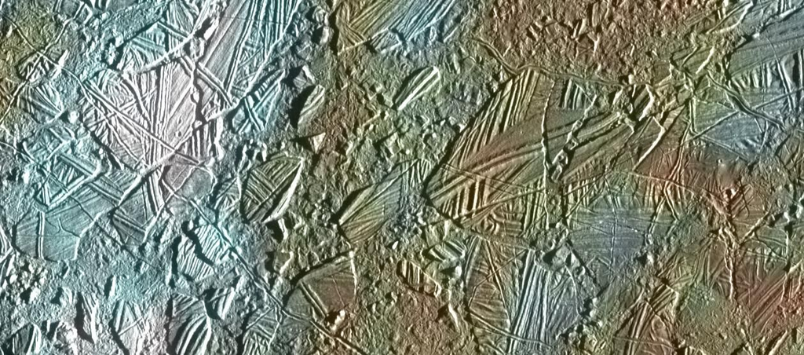

**Broken ice** at Conamara, about 70 km across (colours enhanced): blocks that shifted and refroze. NASA/JPL/University of Arizona

[figure not shown]

**Europa Clipper** (artist's concept): 30.5 m long with its solar arrays out, NASA's biggest planetary spacecraft. NASA/JPL-Caltech

Order of magnitude: how much water?

Suppose the ocean is about 100 km deep and covers the whole moon (Europa's radius is 1,560 km). All of Earth's oceans hold about $1.3\times10^{9}$ km³.

**Reveal**

Volume $\approx$ surface area $\times$ depth $= 4\pi R^2 \times 100\ \text{km} = 4\pi(1560)^2(100) = 3\times10^{9}$ km³. That's $\dfrac{3\times10^{9}}{1.3\times10^{9}} \approx \boxed{2\text{ to }3}$ times all the water in Earth's oceans, on a moon smaller than ours.

Cut it open: Europa and Ganymede

[interactive chart not shown]

Investigate: move the magnifier over Europa and click what you find

[interactive chart not shown]

Show me where to lookFound 0 of 6

There are six kinds of things to find. Drag or move over the picture to magnify, then click.

Put the rafts back: Conamara Chaos

This patch of ice broke into rafts that drifted apart and turned. Drag each raft back into place, and use the ridges as clues: a ridge on one raft should line up with the same ridge on its neighbour. Rotate the selected raft with the buttons (or the scroll wheel).

[interactive chart not shown]

0 of 6 rafts in place

We cut this picture into pieces ourselves, so our cuts don't follow Europa's real cracks. On Europa, scientists fitted the real rafts back together in Galileo's pictures in just this way.

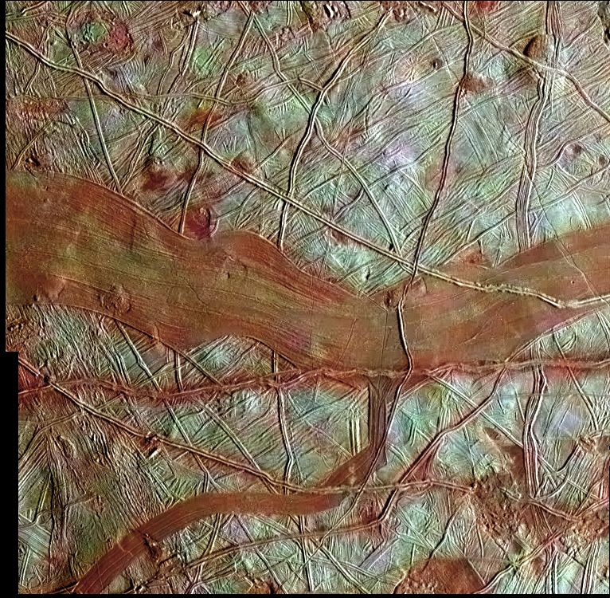

**Reddish bands**, about 160 km across. The colour is probably ice mixed with **salts** from below (perhaps magnesium sulfate), darkened by radiation. In one region, Tara Regio, Hubble even found table salt. NASA/JPL-Caltech/SETI Institute

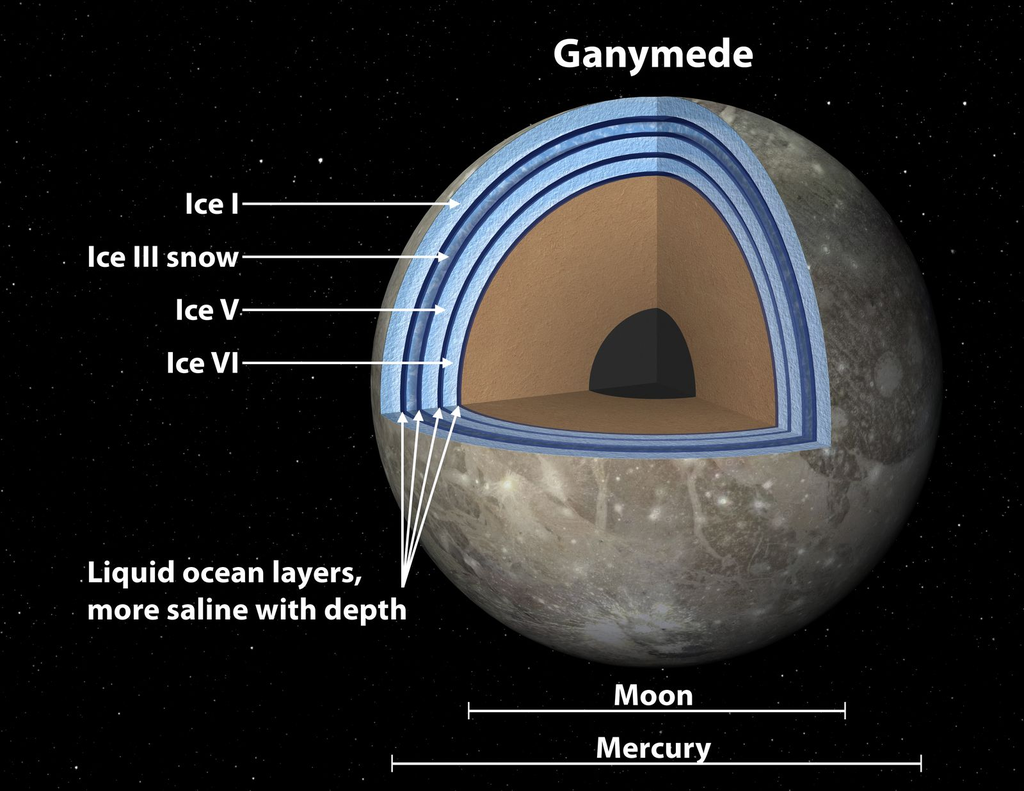

**Ganymede's "club sandwich"**, one possible model: oceans stacked between layers of different kinds of ice. NASA/JPL-Caltech

### The magnetosphere

Jupiter is a giant magnet. Its magnetic field makes an invisible bubble, the **magnetosphere**, that pushes back the wind of particles from the Sun. Toward the Sun it reaches 50 to 100 Jupiter radii; away from the Sun its tail stretches past Saturn's orbit. Io's volcanoes feed it: they throw out about a ton of gas every second, which gets charged and swept into a ring around Jupiter, the **Io plasma torus**. Particles running down the field lines light up **auroras** at the poles, like our northern lights but bigger than Earth.

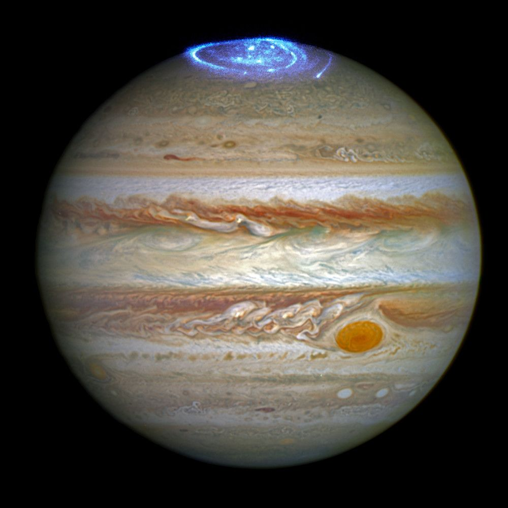

**Auroras at Jupiter's north pole**, in ultraviolet light, bigger than Earth and never switching off. NASA, ESA

[figure not shown]

**Cyclones around the south pole**, seen by Juno in infrared (heat) light. NASA/JPL-Caltech/SwRI/ASI/INAF/JIRAM

The bubble, to scale

[interactive chart not shown]

Measure: how big would it look in our sky?

If our eyes could see it, the magnetosphere is about 150 Jupiter radii across ($1.1\times10^{7}$ km), and at opposition Jupiter is 4.2 AU away ($6.3\times10^{8}$ km). The full Moon is 0.52° across.

**Reveal**

$\tan\theta = \dfrac{1.1\times10^{7}\ \text{km}}{6.3\times10^{8}\ \text{km}} = 0.017$, so $\theta = \boxed{1.0^\circ}$, about **twice the width of the full Moon**. The biggest thing in the solar system, and we can't see it.

If you could see it: the magnetosphere and the full Moon, same scale

[interactive chart not shown]

**Io's footprint.** Io moves through Jupiter's magnetic field like a wire through a magnet, which drives an electric current of about 3 million amps along the field lines to Jupiter. Where that current hits Jupiter's air it makes its own bright spot in the aurora, with a glowing trail behind it. Europa and Ganymede make fainter footprints.

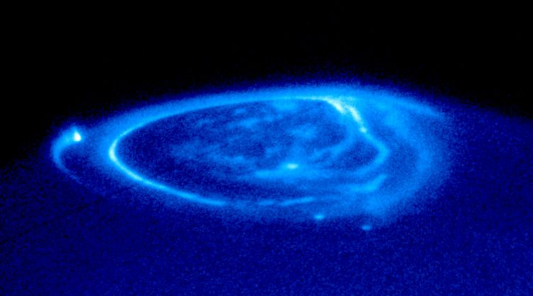

**Moon footprints in the aurora** (Hubble, ultraviolet, 1998). Io's footprint is the bright spot with a tail at the left edge; Ganymede's is near the middle, with Europa's just below and to its right. NASA and the Hubble Heritage Team (STScI/AURA); J. Clarke (University of Michigan)

**Radiation.** The magnetosphere traps fast electrons and ions, like Earth's Van Allen belts but far stronger. The closer to Jupiter, the worse it gets. This is why **Europa Clipper never orbits Europa**: it swoops past 49 times and retreats to calmer space in between, with its electronics inside a metal vault with walls up to 9 mm thick. In orbit around Europa it would last only months.

Radiation dosimeter: where would you stand?

[interactive chart not shown]

Guess first: rank the places from safest to deadliest, then tap each one.

Geiger counter sound

Dose is measured in sieverts (Sv). Doses on the moons' surfaces are commonly quoted estimates (Ringwald 2000), good to about a factor of ten; the ones for Earth, the space station and Mars are measured.

## Which moon, which storm?

[figure not shown]

Pick what you are looking at, then reveal. Keyboard: ← → to move, space to reveal. On a phone, swipe.

**Sources and further reading**

Want to dig deeper? Each title links straight to the original.

**Start here**

- [Jupiter](https://science.nasa.gov/jupiter/) (NASA): the planet's home page: size, weather, moons and the missions that went there.
- [Jupiter facts](https://science.nasa.gov/jupiter/jupiter-facts/) (NASA): short answers on the metallic hydrogen, the fuzzy core, the cloud layers and all 115 moons.

**Missions**

- [Juno](https://science.nasa.gov/mission/juno/) (NASA): the spacecraft orbiting Jupiter since 2016, flying over the poles and through the radiation belts.
- [Europa Clipper](https://science.nasa.gov/mission/europa-clipper/) (NASA): launched October 2024, arriving April 2030. Why it swoops past Europa about 50 times instead of orbiting it.
- [How NASA is protecting Europa Clipper from radiation](https://www.jpl.nasa.gov/news/how-nasa-is-protecting-europa-clipper-from-space-radiation/) (NASA JPL): the vault that keeps its electronics alive.

**Clouds and the Great Red Spot**

- [Hubble tracks the outer planets every year](https://science.nasa.gov/missions/hubble/nasas-hubble-celebrates-decade-of-tracking-outer-planets/) (NASA): the program that made this page's Jupiter maps.
- [The Great Red Spot behaves like a stress ball](https://science.nasa.gov/missions/hubble/nasas-hubble-watches-jupiters-great-red-spot-behave-like-a-stress-ball/) (NASA, 2024): the storm wobbles and changes shape every 90 days.
- [140 years of Great Red Spot measurements](https://doi.org/10.3847/1538-3881/aaae01): the research paper behind this page's shrinking-Spot graph. Free to read. Simon et al. 2018, The Astronomical Journal
- [Jupiter's jet-stream winds, measured from Hubble](https://doi.org/10.1016/j.icarus.2017.06.007): the wind speeds used on this page. Summary free; full paper behind a paywall. Tollefson et al. 2017, Icarus

**Inside Jupiter**

- [Juno's gravity measurements imply a fuzzy core](https://doi.org/10.3847/PSJ/ac7ec8): how we know the core is spread out. Free to read. Militzer et al. 2022, The Planetary Science Journal
- [More internal heat for Jupiter](https://doi.org/10.1038/s41467-018-06107-2): Cassini's measurement that Jupiter gives off about twice the heat it gets from the Sun. Free to read. Li et al. 2018, Nature Communications

**The moons**

- [Lava lakes on Io](https://www.jpl.nasa.gov/news/nasas-juno-gets-a-close-up-look-at-lava-lakes-on-jupiters-moon-io/) (NASA JPL): Juno's infrared view of Io's volcanoes.
- [Juno measures Europa's ice shell](https://www.jpl.nasa.gov/news/nasas-juno-measures-thickness-of-europas-ice-shell/) (NASA JPL, 2025): about 29 km of cold ice on top.
- [Table salt spotted on Europa](https://science.nasa.gov/missions/hubble/table-salt-compound-spotted-on-europa/) (NASA, 2019): a clue that ocean water reaches the surface.
- [Webb finds carbon on Europa](https://science.nasa.gov/missions/webb/nasas-webb-finds-carbon-source-on-surface-of-jupiters-moon-europa/) (NASA, 2023): carbon dioxide in the same salty region, probably from the ocean.
- [Hubble finds Ganymede's hidden ocean](https://science.nasa.gov/missions/hubble/nasas-hubble-observations-suggest-underground-ocean-on-jupiters-largest-moon/) (NASA, 2015): found by watching its aurora rock back and forth.
- [Ganymede's "club sandwich" of oceans and ice](https://www.jpl.nasa.gov/news/ganymede-may-harbor-club-sandwich-of-oceans-and-ice/) (NASA JPL, 2014): the layered model in the cutaway.

The surface radiation doses in the dosimeter are widely quoted estimates from R. Ringwald (California State University, Fresno, 2000); the Earth, space station and Mars values come from NASA and the Curiosity rover.

**Image and data credits**

Jupiter maps and the Red Spot and Oval BA close-ups: Hubble OPAL (NASA, ESA, A. Simon (GSFC), M. H. Wong, and the OPAL team; CC BY 4.0). Winds: Tollefson et al. 2017, Icarus 296. Red Spot lengths 1880–2017: Simon et al. 2018, AJ 155. Ganymede and Callisto maps: NASA/JPL/USGS via NASA Trek.  
Great Red Spot in true colour (PIA21775): enhanced image by Björn Jónsson (CC BY-NC-SA), based on images courtesy NASA/JPL-Caltech/SwRI/MSSS. Great Red Spot shrinking (heic1410): NASA, ESA, and A. Simon (GSFC). Jupiter's south-pole cyclones (PIA23556): NASA/JPL-Caltech/SwRI/ASI/INAF/JIRAM. Jupiter's auroras (heic1613a): NASA, ESA (CC BY 4.0). Io in true colour (PIA02308): NASA/JPL/University of Arizona. Io's plumes (PIA00703): NASA/JPL. Europa's Conamara Chaos (PIA01127): NASA/JPL/University of Arizona. Europa from Juno (PIA25695): image data NASA/JPL-Caltech/SwRI/MSSS, processing Kevin M. Gill (CC BY 3.0). The Galilean moons and the Great Red Spot to scale (PIA00600): NASA/JPL/DLR. Moon footprints in Jupiter's aurora (PIA03155): NASA and the Hubble Heritage Team (STScI/AURA), acknowledgment NASA/ESA, John Clarke (University of Michigan). Reddish bands on Europa (PIA18413): NASA/JPL-Caltech/SETI Institute. Ganymede's layered interior (PIA18005): NASA/JPL-Caltech. Europa Clipper (PIA26433): NASA/JPL-Caltech. Full list with links: img/CREDITS.md.